# Clase 22. Datos Panel – VAR(p)

Benjamin Oliva & Omar Alfaro-Rivera

30/11/2021

# Ejemplo 1: Download data

We used the dynamic panel literature by Arellano and Bond (1991), Blundell and Bond (1998) and Roodman (2009b). This data set describes employment, wages, capital and output of 140 firms in the United Kingdom from 1976 to 1984. We estimate: Employment is explained by past values of employment (“l” lags), current and first lag of wages and output and current value of capital.

```
##  [1] "c1"       "ind"      "year"     "emp"      "wage"     "cap"
##  [7] "indoutpt" "n"        "w"        "k"        "ys"       "rec"
## [13] "yearm1"   "id"       "nL1"      "nL2"      "wL1"      "kL1"
## [19] "kL2"      "ysL1"     "ysL2"     "yr1976"   "yr1977"   "yr1978"
## [25] "yr1979"   "yr1980"   "yr1981"   "yr1982"   "yr1983"   "yr1984"
```

```
##    c1 ind year   emp    wage    cap indoutpt        n        w          k
## 1 1-1   7 1977 5.041 13.1516 0.5894  95.7072 1.617604 2.576543 -0.5286502
## 2 2-1   7 1978 5.600 12.3018 0.6318  97.3569 1.722767 2.509746 -0.4591824
## 3 3-1   7 1979 5.015 12.8395 0.6771  99.6083 1.612433 2.552526 -0.3899363
## 4 4-1   7 1980 4.715 13.8039 0.6171 100.5501 1.550749 2.624951 -0.4827242
## 5 5-1   7 1981 4.093 14.2897 0.5076  99.5581 1.409278 2.659539 -0.6780615
## 6 6-1   7 1982 3.166 14.8681 0.4229  98.6151 1.152469 2.699218 -0.8606195
##         ys rec yearm1 id      nL1      nL2      wL1        kL1        kL2
## 1 4.561294   1   1977  1       NA       NA       NA         NA         NA
## 2 4.578383   2   1977  1 1.617604       NA 2.576543 -0.5286502         NA
## 3 4.601245   3   1978  1 1.722767 1.617604 2.509746 -0.4591824 -0.5286502
## 4 4.610656   4   1979  1 1.612433 1.722767 2.552526 -0.3899363 -0.4591824
## 5 4.600741   5   1980  1 1.550749 1.612433 2.624951 -0.4827242 -0.3899363
## 6 4.591224   6   1981  1 1.409278 1.550749 2.659539 -0.6780615 -0.4827242
##       ysL1     ysL2 yr1976 yr1977 yr1978 yr1979 yr1980 yr1981 yr1982 yr1983
## 1       NA       NA      0      1      0      0      0      0      0      0
## 2 4.561294       NA      0      0      1      0      0      0      0      0
## 3 4.578383 4.561294      0      0      0      1      0      0      0      0
## 4 4.601245 4.578383      0      0      0      0      1      0      0      0
## 5 4.610656 4.601245      0      0      0      0      0      1      0      0
## 6 4.600741 4.610656      0      0      0      0      0      0      1      0
##   yr1984
## 1      0
## 2      0
## 3      0
## 4      0
## 5      0
## 6      0
```

## Estimación

```r
#?pvargmm

Arellano_Bond_1991_table4b <- pvargmm( dependent_vars = c("n"),
                                       lags = 2,
                                       exog_vars = c("w", "wL1", "k", "ys", "ysL1", "yr1979", "yr1980", "yr1981", "yr1982",
                                                      "yr1983", "yr1984"),
                                       transformation = "fd", data = abdata,  panel_identifier = c("id", "year"),
                                       steps = c("twostep"),
                                       system_instruments = FALSE,
                                       max_instr_dependent_vars = 99,
                                       min_instr_dependent_vars = 2L,
                                       collapse = FALSE)
```

```r
summary(Arellano_Bond_1991_table4b)
```

**Dynamic Panel VAR estimation, two-step GMM**

Transformation: *First-differences*  
Group variable: *id*  
Time variable: *year*  
Number of observations = *611*  
Number of groups = *140*  
Obs per group: min = *4*  
Obs per group: avg = *4.36428571428571*  
Obs per group: max = *6*  
Number of instruments = *38*

|  | n |
| --- | --- |
| lag1_n | 0.4742* |
|  | (0.1854) |
| lag2_n | -0.0530 |
|  | (0.0517) |
| w | -0.5132*** |
|  | (0.1456) |
| wL1 | 0.2246 |
|  | (0.1419) |
| k | 0.2927*** |
|  | (0.0626) |
| ys | 0.6098*** |
|  | (0.1563) |
| ysL1 | -0.4464* |
|  | (0.2173) |
| yr1979 | 0.0105 |
|  | (0.0099) |
| yr1980 | 0.0247 |
|  | (0.0158) |
| yr1981 | -0.0158 |
|  | (0.0267) |
| yr1982 | -0.0374 |
|  | (0.0300) |
| yr1983 | -0.0393 |
|  | (0.0347) |
| yr1984 | -0.0495 |
|  | (0.0349) |

***p < 0.001; **p < 0.01; *p < 0.05

**Instruments for equation**

Standard  
*w, wL1, k, ys, ysL1, yr1979, yr1980, yr1981, yr1982, yr1983, yr1984*

GMM-type  
Dependent vars: L(2,6))  
Collapse = FALSE

**Hansen test of overid. restrictions:** chi2(25) = 30.11 Prob > chi2 = 0.22  
(Robust, but weakened by many instruments.)

# Ejemplo 2

We used the panel data set consists of 265 Swedish municipalities and covers 9 years (1979-1987). These variables include total expenditures (expenditures), total own-source revenues (revenues) and intergovernmental grants received by the municipality (grants). Source: Dahlberg and Johansson (2000)

Grants from the central to the local government are of three kinds: support to municipalities with small tax capacity, grants toward the running of certain local government activities and grants toward certain investments.

```r
data("Dahlberg")

names(Dahlberg)
```

```
## [1] "id"           "year"         "expenditures" "revenues"     "grants"
```

```r
head(Dahlberg)
```

```
##    id year expenditures  revenues    grants
## 1 114 1979    0.0229736 0.0181770 0.0054429
## 2 114 1980    0.0266307 0.0209142 0.0057304
## 3 114 1981    0.0273253 0.0210836 0.0056647
## 4 114 1982    0.0288704 0.0234310 0.0058859
## 5 114 1983    0.0226474 0.0179979 0.0055908
## 6 114 1984    0.0215601 0.0179949 0.0047536
```

# Estimación

```r
ex1_dahlberg_data <- pvargmm(dependent_vars = c("expenditures", "revenues", "grants"),
          lags = 1,
          transformation = "fod",
          data = Dahlberg,
          panel_identifier=c("id", "year"),
          steps = c("twostep"),
          system_instruments = FALSE,
          max_instr_dependent_vars = 99,
          max_instr_predet_vars = 99,
          min_instr_dependent_vars = 2L,
          min_instr_predet_vars = 1L,
          collapse = FALSE
  )
summary(ex1_dahlberg_data)
```

**Dynamic Panel VAR estimation, two-step GMM**

Transformation: *Forward orthogonal deviations*  
Group variable: *id*  
Time variable: *year*  
Number of observations = *1855*  
Number of groups = *265*  
Obs per group: min = *7*  
Obs per group: avg = *7*  
Obs per group: max = *7*  
Number of instruments = *252*

|  | expenditures | revenues | grants |
| --- | --- | --- | --- |
| lag1_expenditures | 0.2846*** | 0.2583** | 0.0167 |
|  | (0.0664) | (0.0795) | (0.0172) |
| lag1_revenues | -0.0470 | 0.0588 | -0.0405** |
|  | (0.0637) | (0.0726) | (0.0151) |
| lag1_grants | -1.6746*** | -2.2367*** | 0.3204*** |
|  | (0.2818) | (0.2846) | (0.0521) |

***p < 0.001; **p < 0.01; *p < 0.05

**Instruments for equation**

Standard

GMM-type  
Dependent vars: L(2,7))  
Collapse = FALSE

**Hansen test of overid. restrictions:** chi2(243) = 263.01 Prob > chi2 = 0.18  
(Robust, but weakened by many instruments.)

## model selection procedure of Andrews and Lu (2001) to select the optimal lag length for our example

```r
Andrews_Lu_MMSC(ex1_dahlberg_data)
```

```
## $MMSC_BIC
## [1] -1610.877
##
## $MMSC_AIC
## [1] -234.9924
##
## $MMSC_HQIC
## [1] -792.3698
```

```r
ex2_dahlberg_data <- pvargmm(dependent_vars = c("expenditures", "revenues", "grants"),
                             lags = 2,
                             transformation = "fod",
                             data = Dahlberg,
                             panel_identifier=c("id", "year"),
                             steps = c("twostep"),
                             system_instruments = FALSE,
                             max_instr_dependent_vars = 99,
                             max_instr_predet_vars = 99,
                             min_instr_dependent_vars = 2L,
                             min_instr_predet_vars = 1L,
                             collapse = FALSE)
summary(ex2_dahlberg_data)
```

**Dynamic Panel VAR estimation, two-step GMM**

Transformation: *Forward orthogonal deviations*  
Group variable: *id*  
Time variable: *year*  
Number of observations = *1590*  
Number of groups = *265*  
Obs per group: min = *6*  
Obs per group: avg = *6*  
Obs per group: max = *6*  
Number of instruments = *243*

|  | expenditures | revenues | grants |
| --- | --- | --- | --- |
| lag1_expenditures | 0.2572** | 0.2486* | 0.0135 |
|  | (0.0893) | (0.1018) | (0.0178) |
| lag1_revenues | -0.1219 | -0.0634 | -0.0293 |
|  | (0.0879) | (0.0997) | (0.0171) |
| lag1_grants | -3.0718*** | -3.5849*** | 0.1581* |
|  | (0.5941) | (0.6168) | (0.0636) |
| lag2_expenditures | -0.0247 | 0.0252 | 0.0178 |
|  | (0.0791) | (0.0834) | (0.0157) |
| lag2_revenues | -0.2584** | -0.2446** | -0.0237 |
|  | (0.0785) | (0.0800) | (0.0157) |
| lag2_grants | -1.5265*** | -1.6687*** | 0.0702 |
|  | (0.1873) | (0.2113) | (0.0586) |

***p < 0.001; **p < 0.01; *p < 0.05

**Instruments for equation**

Standard

GMM-type  
Dependent vars: L(2,6))  
Collapse = FALSE

**Hansen test of overid. restrictions:** chi2(225) = 260.11 Prob > chi2 = 0.054  
(Robust, but weakened by many instruments.)

```r
Andrews_Lu_MMSC(ex2_dahlberg_data)
```

```
## $MMSC_BIC
## [1] -1486.935
##
## $MMSC_AIC
## [1] -213.8917
##
## $MMSC_HQIC
## [1] -734.1071
```

# stability of the autoregressive process:

```r
stab_ex1_dahlberg_data <- stability(ex1_dahlberg_data)

print(stab_ex1_dahlberg_data)
```

```
## Eigenvalue stability condition:
##
##              Eigenvalue    Modulus
## 1 0.5370657+0.00000000i 0.53706574
## 2 0.0633651+0.06442426i 0.09036383
## 3 0.0633651-0.06442426i 0.09036383
##
## All the eigenvalues lie inside the unit circle.
## PVAR satisfies stability condition.
```

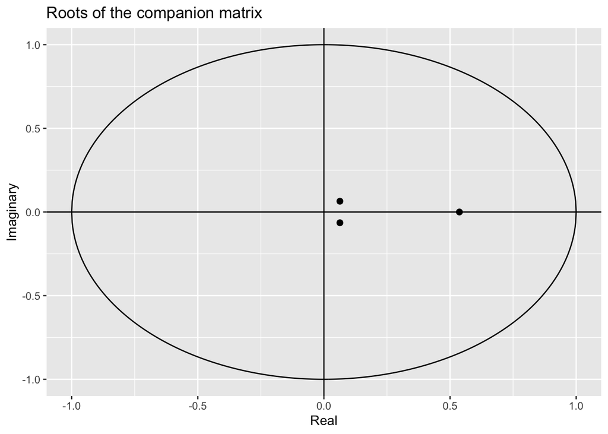

```r
plot(stab_ex1_dahlberg_data)
```

# generate impulse response functions.

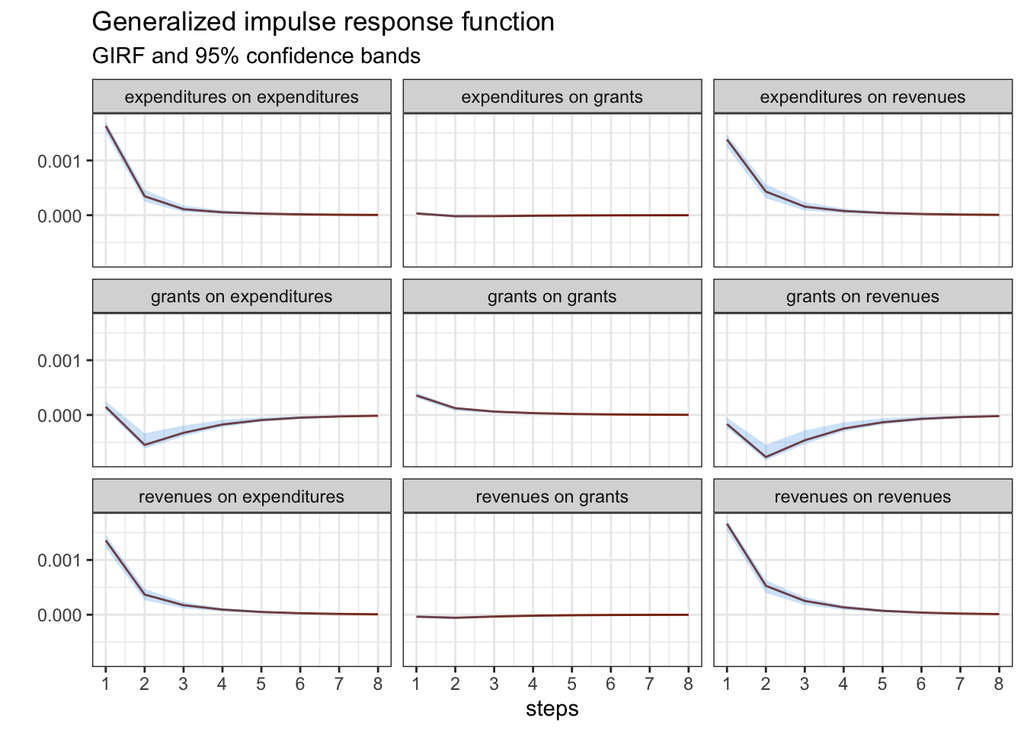

```r
ex1_dahlberg_data_oirf <-  oirf(ex1_dahlberg_data, n.ahead = 8)

ex1_dahlberg_data_girf <-  girf(ex1_dahlberg_data, n.ahead = 8, ma_approx_steps= 8)

ex1_dahlberg_data_bs <-  bootstrap_irf(ex1_dahlberg_data, typeof_irf = c("GIRF"),
                                       n.ahead = 8,
                                       nof_Nstar_draws = 500,
                                       confidence.band = 0.95)

plot(ex1_dahlberg_data_girf, ex1_dahlberg_data_bs)
```